# IODS course project

Lets summarize data and present mean and standard error of weight by treatment and week.

```r
n <- ratsl$Time %>% unique() %>% length()

ratss <- ratsl %>%
  group_by(Group, Time) %>%
  summarise( mean = mean(weight), se = sd(weight)/sqrt(n)) %>%
  ungroup()

# Glimpse the data
glimpse(ratss)
```

```
## Rows: 33
## Columns: 4
## $ Group <fct> 1, 1, 1, 1, 1, 1, 1, 1, 1, 1, 1, 2, 2, 2, 2, 2, 2, 2, 2, 2, 2...
## $ Time  <int> 1, 8, 15, 22, 29, 36, 43, 44, 50, 57, 64, 1, 8, 15, 22, 29, 3...
## $ mean  <dbl> 250.625, 255.000, 254.375, 261.875, 264.625, 265.000, 267.375...
## $ se    <dbl> 4.589478, 3.947710, 3.460116, 4.100800, 3.333956, 3.552939, 3...
```

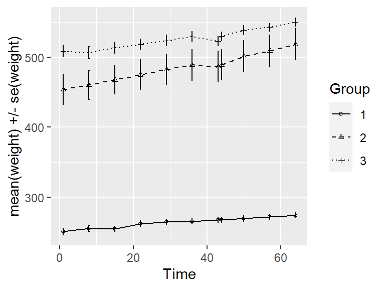

```r
# Plot the mean profiles
ggplot(ratss, aes(x = Time, y = mean, linetype = Group, shape = Group)) +
  geom_line() +
  scale_linetype_manual(values = c(1,2,3)) +
  geom_point(size=1) +
  scale_shape_manual(values = c(1,2,3))+
  geom_errorbar(aes(ymin=mean-se, ymax=mean+se, linetype="1"), width=0.3) +
  scale_y_continuous(name = "mean(weight) +/- se(weight)")
```

Results are similar as we saw from individual data - first diet group has lower weights and lower variability. Second diet group has highest variability (probably related with outlier) and third group has highest weight. From this graph we can assume that second and third group gaining weight more rapidly compared diet group 1.

We can present also medians and boxplots. From there we see the outlier, lets try to let it out and see the results again.

```r
ratsl10 <- ratsl %>%
  filter(Time > 1) %>%
  group_by(Group, ID) %>%
  summarise( mean=mean(weight) ) %>%
  ungroup()
head(ratsl10, n=3 )
```

```
## # A tibble: 3 x 3
##   Group ID     mean
##   <fct> <fct> <dbl>
## 1 1     1      263.
## 2 1     2      239.
## 3 1     3      262.
```

```r
# Glimpse the data
glimpse(ratsl10)
```

```
## Rows: 16
## Columns: 3
## $ Group <fct> 1, 1, 1, 1, 1, 1, 1, 1, 2, 2, 2, 2, 3, 3, 3, 3
## $ ID    <fct> 1, 2, 3, 4, 5, 6, 7, 8, 9, 10, 11, 12, 13, 14, 15, 16
## $ mean  <dbl> 263.2, 238.9, 261.7, 267.2, 270.9, 276.2, 274.6, 267.5, 443.9...
```

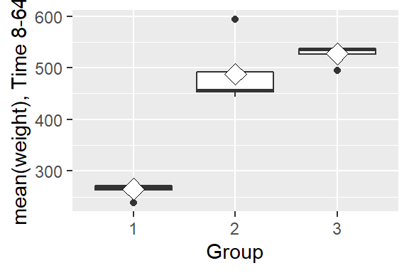

```r
# Draw a boxplot of the mean versus treatment
ggplot(ratsl10, aes(x = Group, y = mean)) +
  geom_boxplot() +
  stat_summary(fun = "mean", geom = "point", shape=23, size=4, fill = "white") +
  scale_y_continuous(name = "mean(weight), Time 8-64")
```

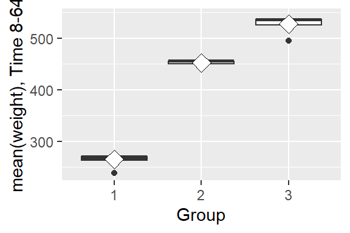

```r
# Create a new data by filtering the outlier and adjust the ggplot code the draw the plot again with the new data
ratsl10s <- ratsl10 %>%  filter(mean<550)

ggplot(ratsl10s, aes(x = Group, y = mean)) +
  geom_boxplot() +
  stat_summary(fun = "mean", geom = "point", shape=23, size=4, fill = "white") +
  scale_y_continuous(name = "mean(weight), Time 8-64")
```

Lets test the differences. I will do t-test between groups and use Bonferroni correction to avoid multiple testing problem. But first - I present standard deviations of the groups, to decide are the deviations equal or not.

```r
tapply(ratsl10s$mean, ratsl10s$Group, sd)
```

```
##         1         2         3
## 11.703693  7.410128 21.712362
```

```r
# Perform a two-sample t-test
t1=t.test(mean[Group!=3] ~ Group[Group!=3], data = ratsl10s, var.equal = TRUE)
t2=t.test(mean[Group!=2] ~ Group[Group!=2], data = ratsl10s, var.equal = FALSE)
t3=t.test(mean[Group!=1] ~ Group[Group!=1], data = ratsl10s, var.equal = FALSE)
```

[output not shown]

All means are statistically significantly different.

Now I add weight’s baseline values from original data as a new variable to the summary data and estimate linear regression model.

```r
ratsl10s <- ratsl10 %>%
  mutate(baseline = rats$WD1)

str(ratsl10s)
```

```
## tibble [16 x 4] (S3: tbl_df/tbl/data.frame)
##  $ Group   : Factor w/ 3 levels "1","2","3": 1 1 1 1 1 1 1 1 2 2 ...
##  $ ID      : Factor w/ 16 levels "1","2","3","4",..: 1 2 3 4 5 6 7 8 9 10 ...
##  $ mean    : num [1:16] 263 239 262 267 271 ...
##  $ baseline: int [1:16] 240 225 245 260 255 260 275 245 410 405 ...
```

Fit the linear model with the mean as the response

```r
fit <- lm(mean ~ factor(Group) + baseline, data = ratsl10s)
summary(fit)
```

```
##
## Call:
## lm(formula = mean ~ factor(Group) + baseline, data = ratsl10s)
##
## Residuals:
##     Min      1Q  Median      3Q     Max
## -23.905  -4.194   2.190   7.577  14.800
##
## Coefficients:
##                Estimate Std. Error t value Pr(>|t|)
## (Intercept)    33.16375   21.87657   1.516   0.1554
## factor(Group)2 34.85753   18.82308   1.852   0.0888 .
## factor(Group)3 23.67526   23.25324   1.018   0.3287
## baseline        0.92513    0.08572  10.793 1.56e-07 ***
## ---
## Signif. codes:  0 '***' 0.001 '**' 0.01 '*' 0.05 '.' 0.1 ' ' 1
##
## Residual standard error: 11.68 on 12 degrees of freedom
## Multiple R-squared:  0.9936, Adjusted R-squared:  0.992
## F-statistic: 622.1 on 3 and 12 DF,  p-value: 1.989e-13
```

```r
anova(fit)
```

```
## Analysis of Variance Table
##
## Response: mean
##               Df Sum Sq Mean Sq F value    Pr(>F)
## factor(Group)  2 238620  119310  874.89 9.986e-14 ***
## baseline       1  15884   15884  116.48 1.562e-07 ***
## Residuals     12   1636     136
## ---
## Signif. codes:  0 '***' 0.001 '**' 0.01 '*' 0.05 '.' 0.1 ' ' 1
```

Model says that if we adsjust to the baseline weight than mean weights of 2nd and 3rd group are not statistically significantlydifferent from 1st group mean weight. But this analysis does not include the time.

## 6.3 Longitudinal data analysis on **BPRS** data (Chapt 9)

To investigate the use of linear mixed effects models in practice, we will BPRS data

```r
BPRSL = read.csv(file = (paste0(getwd(), "/data/bprsl.csv")), row.names=1)

BPRSL$treatment <- factor(BPRSL$treatment)
BPRSL$subject <- factor(BPRSL$subject)

str(BPRSL)
```

```
## 'data.frame':    360 obs. of  5 variables:
##  $ treatment: Factor w/ 2 levels "1","2": 1 1 1 1 1 1 1 1 1 1 ...
##  $ subject  : Factor w/ 20 levels "1","2","3","4",..: 1 2 3 4 5 6 7 8 9 10 ...
##  $ weeks    : chr  "week0" "week0" "week0" "week0" ...
##  $ bprs     : int  42 58 54 55 72 48 71 30 41 57 ...
##  $ week     : int  0 0 0 0 0 0 0 0 0 0 ...
```

Individual plot of BPRS scores:

[figure not shown]

```r
ggplot(BPRSL, aes(x = week, y = bprs, linetype = subject)) +
  geom_line() +
  scale_linetype_manual(values = rep(1:10, times=4)) +
  facet_grid(. ~ treatment, labeller = label_both) +
  theme(legend.position = "none") +
  scale_y_continuous(name="standardized weight")
```

**Linear regression**

We will fit a multiple linear regression model with bprs as response and week and treatment as explanatory variables (Ignore the repeated-measures structure).

```r
bprsl_reg <- lm(bprs~week + factor(treatment), data=BPRSL)

summary(bprsl_reg)
```

```
##
## Call:
## lm(formula = bprs ~ week + factor(treatment), data = BPRSL)
##
## Residuals:
##     Min      1Q  Median      3Q     Max
## -22.454  -8.965  -3.196   7.002  50.244
##
## Coefficients:
##                    Estimate Std. Error t value Pr(>|t|)
## (Intercept)         46.4539     1.3670  33.982   <2e-16 ***
## week                -2.2704     0.2524  -8.995   <2e-16 ***
## factor(treatment)2   0.5722     1.3034   0.439    0.661
## ---
## Signif. codes:  0 '***' 0.001 '**' 0.01 '*' 0.05 '.' 0.1 ' ' 1
##
## Residual standard error: 12.37 on 357 degrees of freedom
## Multiple R-squared:  0.1851, Adjusted R-squared:  0.1806
## F-statistic: 40.55 on 2 and 357 DF,  p-value: < 2.2e-16
```

Difference between treatment grops is 0.57 points and this is not statistically significant. But each weeh decreases score by 2.2 points and this is significant result.

**The Random Intercept Model**

We will fit the random intercept model for the same two explanatory variables: week and treatment. Fitting a random intercept model allows the linear regression fit for each study subject to differ in intercept from other subjects.

We will use the lme4 package, the random-effects terms distinguished by vertical bars (|).

```r
library(lme4)

# Create a random intercept model
bprs_ref <- lmer(bprs~week + factor(treatment) + (1 | subject), data = BPRSL, REML = FALSE)

# Print the summary of the model
summary(bprs_ref)
```

```
## Linear mixed model fit by maximum likelihood  ['lmerMod']
## Formula: bprs ~ week + factor(treatment) + (1 | subject)
##    Data: BPRSL
##
##      AIC      BIC   logLik deviance df.resid
##   2748.7   2768.1  -1369.4   2738.7      355
##
## Scaled residuals:
##     Min      1Q  Median      3Q     Max
## -3.0481 -0.6749 -0.1361  0.4813  3.4855
##
## Random effects:
##  Groups   Name        Variance Std.Dev.
##  subject  (Intercept)  47.41    6.885
##  Residual             104.21   10.208
## Number of obs: 360, groups:  subject, 20
##
## Fixed effects:
##                    Estimate Std. Error t value
## (Intercept)         46.4539     1.9090  24.334
## week                -2.2704     0.2084 -10.896
## factor(treatment)2   0.5722     1.0761   0.532
##
## Correlation of Fixed Effects:
##             (Intr) week
## week        -0.437
## fctr(trtm)2 -0.282  0.000
```

Treatment effect is not significant, but week effect is - it means that scores are decreasing by the time, but decreas is not different on both groups.

Now we estimate the model where we allow the random intercept and random slope by weeks. So we can take account patients individual differences on time.

```r
# Create a random intercept and random slope model
bprs_ref1 <- lmer(bprs~week + factor(treatment) + (week | subject), data = BPRSL, REML = FALSE)

# print a summary of the model
summary(bprs_ref1)
```

```
## Linear mixed model fit by maximum likelihood  ['lmerMod']
## Formula: bprs ~ week + factor(treatment) + (week | subject)
##    Data: BPRSL
##
##      AIC      BIC   logLik deviance df.resid
##   2745.4   2772.6  -1365.7   2731.4      353
##
## Scaled residuals:
##     Min      1Q  Median      3Q     Max
## -2.8919 -0.6194 -0.0691  0.5531  3.7976
##
## Random effects:
##  Groups   Name        Variance Std.Dev. Corr
##  subject  (Intercept) 64.8222  8.0512
##           week         0.9609  0.9802   -0.51
##  Residual             97.4305  9.8707
## Number of obs: 360, groups:  subject, 20
##
## Fixed effects:
##                    Estimate Std. Error t value
## (Intercept)         46.4539     2.1052  22.066
## week                -2.2704     0.2977  -7.626
## factor(treatment)2   0.5722     1.0405   0.550
##
## Correlation of Fixed Effects:
##             (Intr) week
## week        -0.582
## fctr(trtm)2 -0.247  0.000
```

Random effects residual is smaller compared with first random effects model. But main results are same - treatment effect is not significant, but scores decreasing week by week.

Perform an ANOVA test on the two models:

```r
anova(bprs_ref1, bprs_ref)
```

```
## Data: BPRSL
## Models:
## bprs_ref: bprs ~ week + factor(treatment) + (1 | subject)
## bprs_ref1: bprs ~ week + factor(treatment) + (week | subject)
##           npar    AIC    BIC  logLik deviance  Chisq Df Pr(>Chisq)
## bprs_ref     5 2748.7 2768.1 -1369.4   2738.7
## bprs_ref1    7 2745.4 2772.6 -1365.7   2731.4 7.2721  2    0.02636 *
## ---
## Signif. codes:  0 '***' 0.001 '**' 0.01 '*' 0.05 '.' 0.1 ' ' 1
```

Deviance residuals are significantly smaller on second model.

Lets add interaction of time and treatment.

```r
# create a random intercept and random slope model with the interaction
bprs_ref2 <- lmer(bprs ~ week + treatment + week*treatment + (week | subject), data = BPRSL, REML = FALSE)

# print a summary of the model
summary(bprs_ref2)
```

```
## Linear mixed model fit by maximum likelihood  ['lmerMod']
## Formula: bprs ~ week + treatment + week * treatment + (week | subject)
##    Data: BPRSL
##
##      AIC      BIC   logLik deviance df.resid
##   2744.3   2775.4  -1364.1   2728.3      352
##
## Scaled residuals:
##     Min      1Q  Median      3Q     Max
## -3.0512 -0.6271 -0.0768  0.5288  3.9260
##
## Random effects:
##  Groups   Name        Variance Std.Dev. Corr
##  subject  (Intercept) 64.9964  8.0620
##           week         0.9687  0.9842   -0.51
##  Residual             96.4707  9.8220
## Number of obs: 360, groups:  subject, 20
##
## Fixed effects:
##                 Estimate Std. Error t value
## (Intercept)      47.8856     2.2521  21.262
## week             -2.6283     0.3589  -7.323
## treatment2       -2.2911     1.9090  -1.200
## week:treatment2   0.7158     0.4010   1.785
##
## Correlation of Fixed Effects:
##             (Intr) week   trtmn2
## week        -0.650
## treatment2  -0.424  0.469
## wek:trtmnt2  0.356 -0.559 -0.840
```

```r
# perform an ANOVA test on the two models
anova(bprs_ref2, bprs_ref1)
```

```
## Data: BPRSL
## Models:
## bprs_ref1: bprs ~ week + factor(treatment) + (week | subject)
## bprs_ref2: bprs ~ week + treatment + week * treatment + (week | subject)
##           npar    AIC    BIC  logLik deviance  Chisq Df Pr(>Chisq)
## bprs_ref1    7 2745.4 2772.6 -1365.7   2731.4
## bprs_ref2    8 2744.3 2775.4 -1364.1   2728.3 3.1712  1    0.07495 .
## ---
## Signif. codes:  0 '***' 0.001 '**' 0.01 '*' 0.05 '.' 0.1 ' ' 1
```

Model with interactions is not significantly different from old one, but p-value is very close, so we can keep the new one (with interactions).

Lets draw the plot observed of BPRS individual data and compare it with the fitted values of last model.

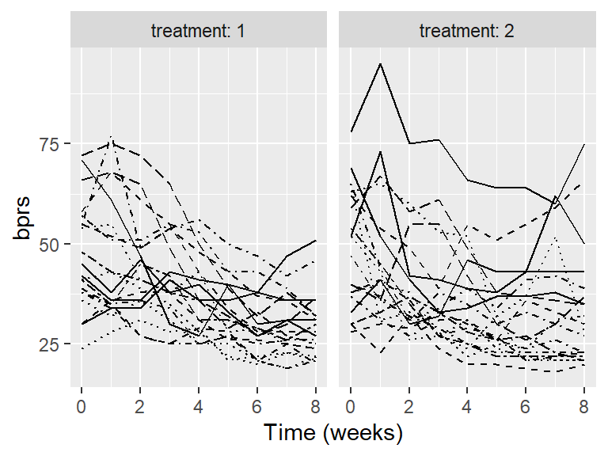

```r
ggplot(BPRSL, aes(x = week, y = bprs, linetype = subject)) +
  geom_line() +
  scale_linetype_manual(values = rep(1:10, times=4)) +
  facet_grid(. ~ treatment, labeller = label_both) +
  scale_x_continuous(name = "Time (weeks)") +
  scale_y_continuous(name = "bprs") +
  theme(legend.position = "none")
```

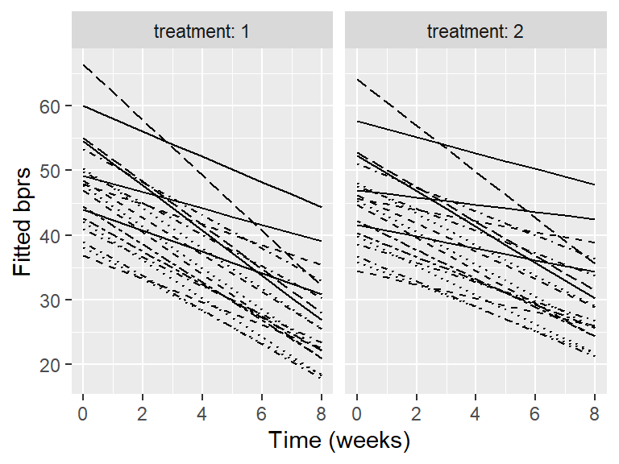

```r
# Create a vector of the fitted values
Fitted <- fitted(bprs_ref2)

# Create a new column fitted to RATSL
BPRSL=BPRSL %>% mutate(Fitted=Fitted)

ggplot(BPRSL, aes(x = week, y = Fitted, linetype = subject)) +
  geom_line() +
  scale_linetype_manual(values = rep(1:10, times=4)) +
  facet_grid(. ~ treatment, labeller = label_both) +
  scale_x_continuous(name = "Time (weeks)") +
  scale_y_continuous(name = "Fitted bprs") +
  theme(legend.position = "none")
```